# Final Project

USUPERVISED LEARNING EXPLORATORY ANALYSIS CLUSTERING

Exploratory analysis, unsupervised learning, reveals hidden patterns or structures within a dataset without any predefined labels or target variable. We can identify natural groupings through clustering, and we can further explore data.

At first, the clusters created didn’t tell us much and we were quite confused. We came to the realization that a lot of scatterplots with our data set didn’t necessarily work quite right because we had a lot of binomial variables. So therefore, finding the average would make our scatterplot much more beneficial and legible for someone that was just glancing at our analysis.

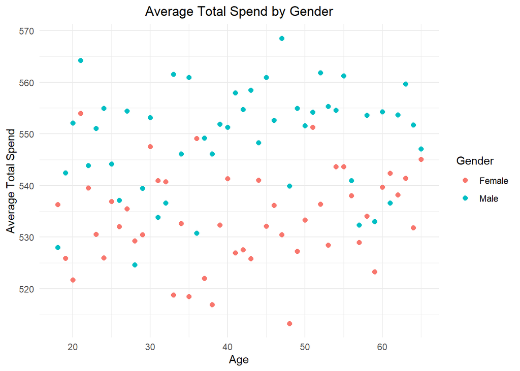

```r
#The first scatterplot below, we looked at average total spend by gender. Focusing on how spending patterns vary by gender. Male seemed to be higher, which was good insight considering, they tended to churn less as seen earlier, compared to women. So, they tend to spend more, and churn less, meaning we should defiantly target males

ggplot(df, aes(x=Age, y=Total.Spend, color=Gender)) +
  stat_summary(fun=mean, geom="point", size=2)+
  labs(x = "Age", y = "Average Total Spend") +
  ggtitle("Average Total Spend by Gender") +
  theme_minimal() +
  theme(plot.title = element_text(hjust = .5))
```

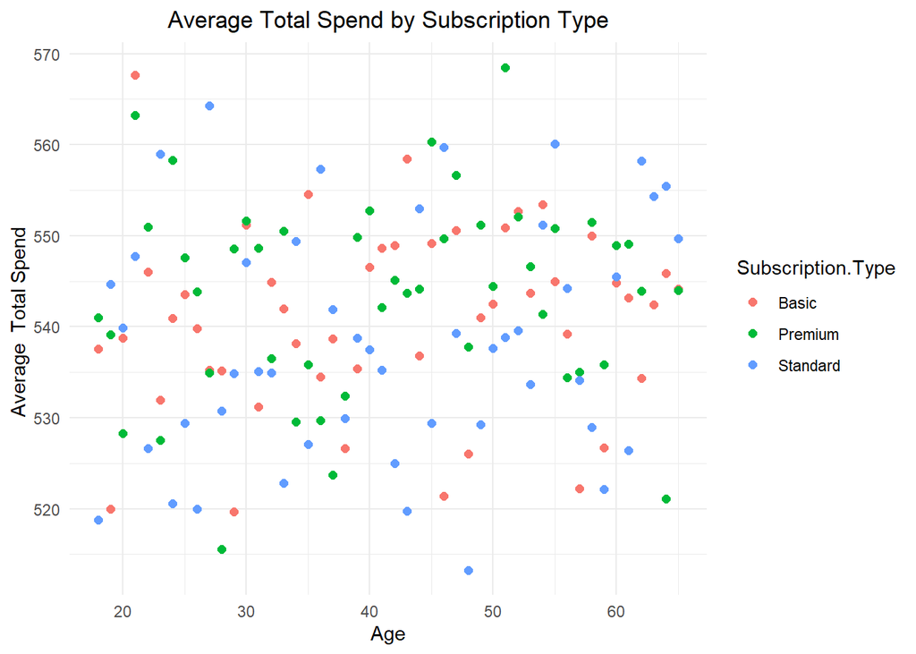

```r
#This results below were rather unexpected; it seems as though the average total spend doesn’t really vary by the type of subscription. There is absolutely no trend, so it could be that the more the client pays for their subscription the less they spend. Which could maybe lead to our  corporation not even really needing all these subscription types, although of course, we would need further analysis to conclude this.

ggplot(df, aes(x=Age, y=Total.Spend, color=Subscription.Type)) +
  stat_summary(fun=mean, geom="point", size=2)+
  labs(x = "Age", y = "Average  Total Spend ") +
  ggtitle("Average Total Spend by Subscription Type") +
  theme_minimal() +
  theme(plot.title = element_text(hjust = .5))
```

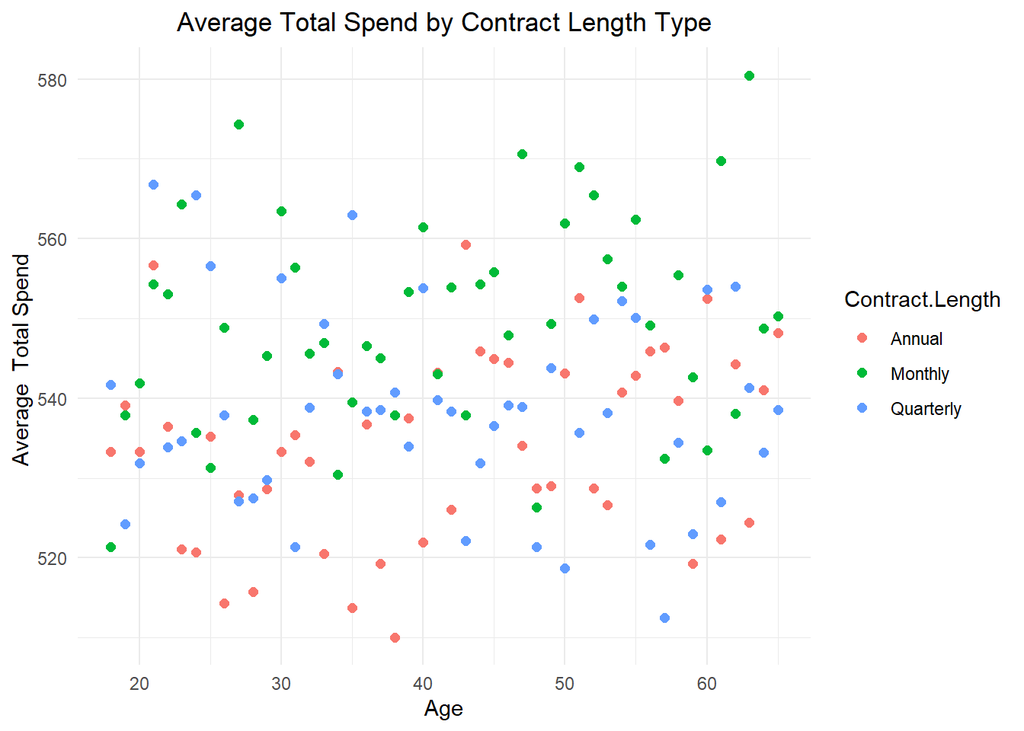

```r
#It appears with the lowest contract length, our customers tended to spend the most. It appears annual members, actually tended to spend less. Again, this could be a psychological thing, with a short contract, because it will end sooner, they will spend more while they have the contract.

ggplot(df, aes(x=Age, y=Total.Spend, color=Contract.Length)) +
  stat_summary(fun=mean, geom="point", size=2)+
  labs(x = "Age", y = "Average  Total Spend ") +
  ggtitle("Average Total Spend by Contract Length Type") +
  theme_minimal() +
  theme(plot.title = element_text(hjust = .5))
```

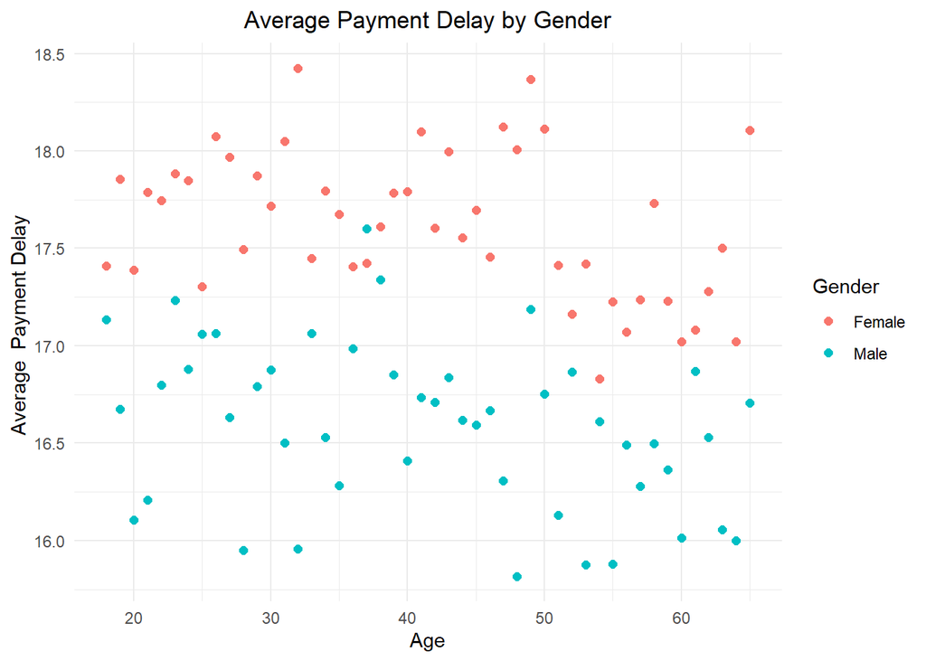

```r
#females had the greatest average payment delay. This is unanticipated honestly. This could maybe tell us, that while committing to a contract with female, perhaps be aware that they may pay in a longer period, and perhaps set some sort of penalty for not paying.


ggplot(df, aes(x=Age, y=Payment.Delay, color=Gender)) +
  stat_summary(fun=mean, geom="point", size=2)+
  labs(x = "Age", y = "Average  Payment Delay ") +
  ggtitle("Average Payment Delay by Gender") +
  theme_minimal() +
  theme(plot.title = element_text(hjust = .5))
```

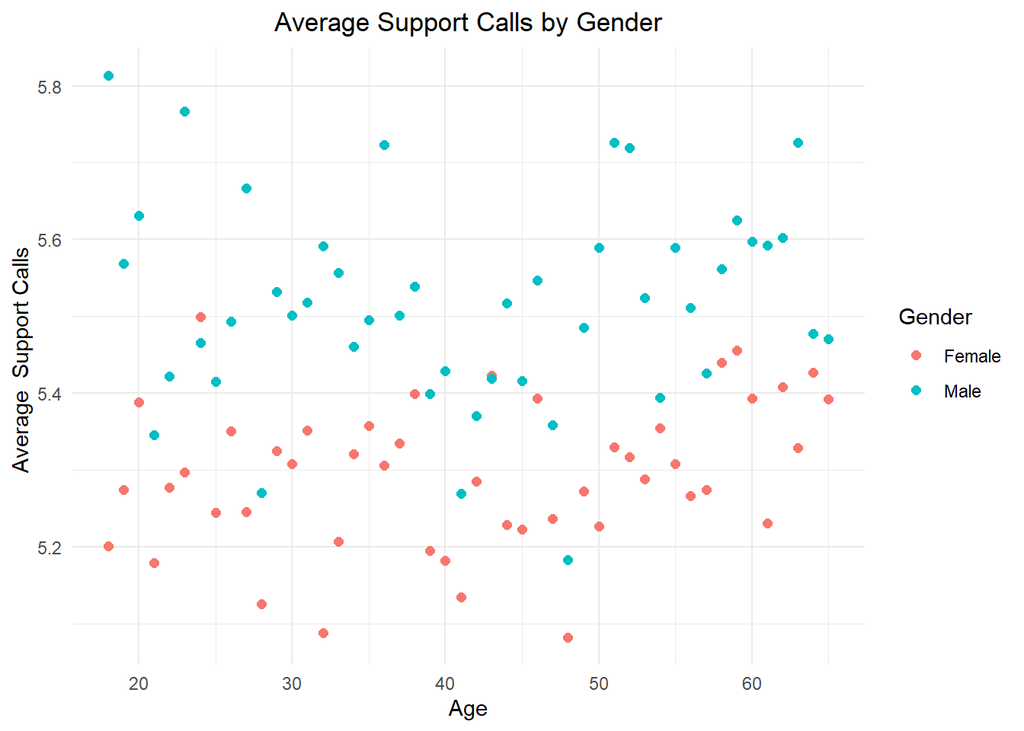

```r
#Males tended to call the most for support. So here, we see that there is a benefit to having female’s customers, they may pay late, however, we extend less resources to them because they don’t call as much, and we do not have to hire as many support callers.


ggplot(df, aes(x=Age, y=Support.Calls, color=Gender)) +
  stat_summary(fun=mean, geom="point", size=2)+
  labs(x = "Age", y = "Average  Support Calls ") +
  ggtitle("Average Support Calls by Gender") +
  theme_minimal() +
  theme(plot.title = element_text(hjust = .5))
```

[figure not shown]

```r
ggplot(df, aes(x=Age, y=Tenure, color=Gender)) +
  stat_summary(fun=mean, geom="point", size=2)+
  labs(x = "Age", y = "Average  Payment Delay ") +
  ggtitle("Average Payment Delay by Gender") +
  theme_minimal() +
  theme(plot.title = element_text(hjust = .5))
```

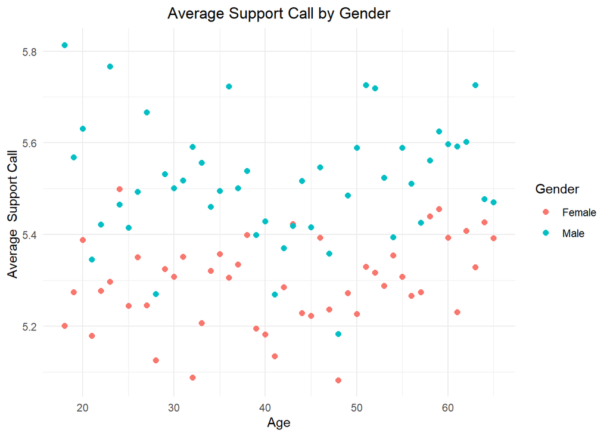

```r
#Males tended to call the most for support. So here, we see that there is a benefit to having female’s customers, they may pay late, however, we extend less resources to them because they don’t call as much, and we do not have to hire as many support callers.

ggplot(df, aes(x=Age, y=Support.Calls, color=Gender)) +
  stat_summary(fun=mean, geom="point", size=2)+
  labs(x = "Age", y = "Average  Support Call ") +
  ggtitle("Average Support Call by Gender") +
  theme_minimal() +
  theme(plot.title = element_text(hjust = .5))
```

Our reason for choosing cluster analysis for unsupervised learning: WE chose this because it provided a conceptual and visually appealing outcome. We could see clusters or groups of data points, and we were able to understand how various indicators impact the churn rate. It is also very useful when discovering natural groupings within the data. Also, Churn rate can be described by a variety of features that when combined, lead to a customer leaving. Cluster analysis gave us wonderful insights and ideas on how to change as a corporation.

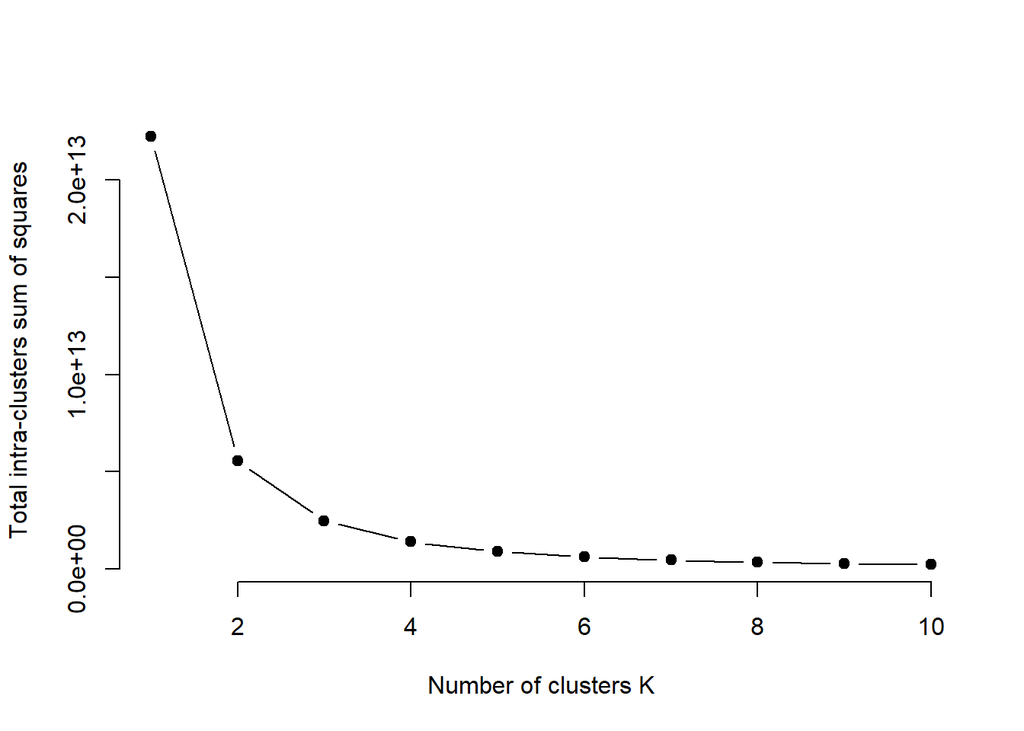

```r
#there is a huge drop at 2 and then from there on, the drop is very minimal, meaning that the time it takes to run, it may not make snese to do much more than 2 or 3 clusters.

iss <- function(k) {
  kmeans(data %>% select_if(is.numeric),k,iter.max=500,nstart=100,algorithm="Lloyd" )$tot.withinss
}
k.values <- 1:10
iss_values <- map_dbl(k.values, iss)

plot(k.values, iss_values,
     type="b", pch = 19, frame = FALSE,
     xlab="Number of clusters K",
     ylab="Total intra-clusters sum of squares")
```

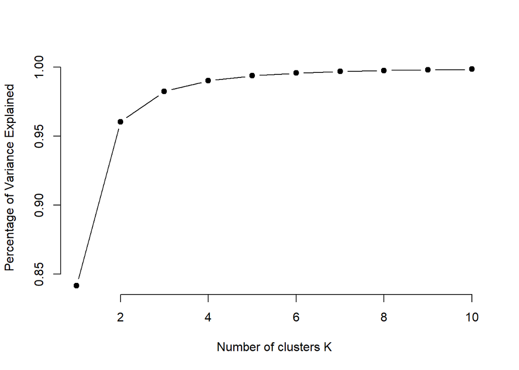

```r
#We are seeing a very similar idea. Either way, 95% variance explained is great, so looking at this, I say not much more than 2 or 3. The change from two-3 is also rather minimal
total_ss <- sum((df %>% select_if(is.numeric) - colMeans(df %>% select_if(is.numeric)))^2)

# Modified function to return percentage of variance explained
iss <- function(k) {
  wss <- kmeans(data %>% select_if(is.numeric), k, iter.max=500, nstart=100, algorithm="Lloyd")$tot.withinss
  return(1 - wss / total_ss)
}

# Rest of the code remains similar
k.values <- 1:10
perc_variance <- map_dbl(k.values, iss)

plot(k.values, perc_variance,
     type="b", pch = 19, frame = FALSE,
     xlab="Number of clusters K",
     ylab="Percentage of Variance Explained")
```

```r
#we decided on two clusters, with the size around 32,000
#
?kmeans
```

```
## starting httpd help server ... done
```

```r
k5<-kmeans(data %>% select_if(is.numeric),2,iter.max=100,nstart=100)
df$ClusterNumber <- k5$cluster
k5
```

```
## K-means clustering with 2 clusters of sizes 32187, 32187
##
## Cluster means:
##   CustomerID      Age   Gender   Tenure Usage.Frequency Support.Calls
## 1      48281 42.50148 1.568801 33.42890        14.62482      5.816852
## 2      16094 41.44049 1.498493 30.56075        15.53565      4.984528
##   Payment.Delay Subscription.Type Contract.Length Total.Spend Last.Interaction
## 1      19.25023          1.999472        1.982508    533.4661         15.47268
## 2      15.01768          1.999596        1.999596    548.5807         15.52503
##       Churn
## 1 0.6892534
## 2 0.2581166
##
## Clustering vector:
##     1     2     3     4     5     6     7     8     9    10    11    12    13
```

[output cut: 9912 more lines]

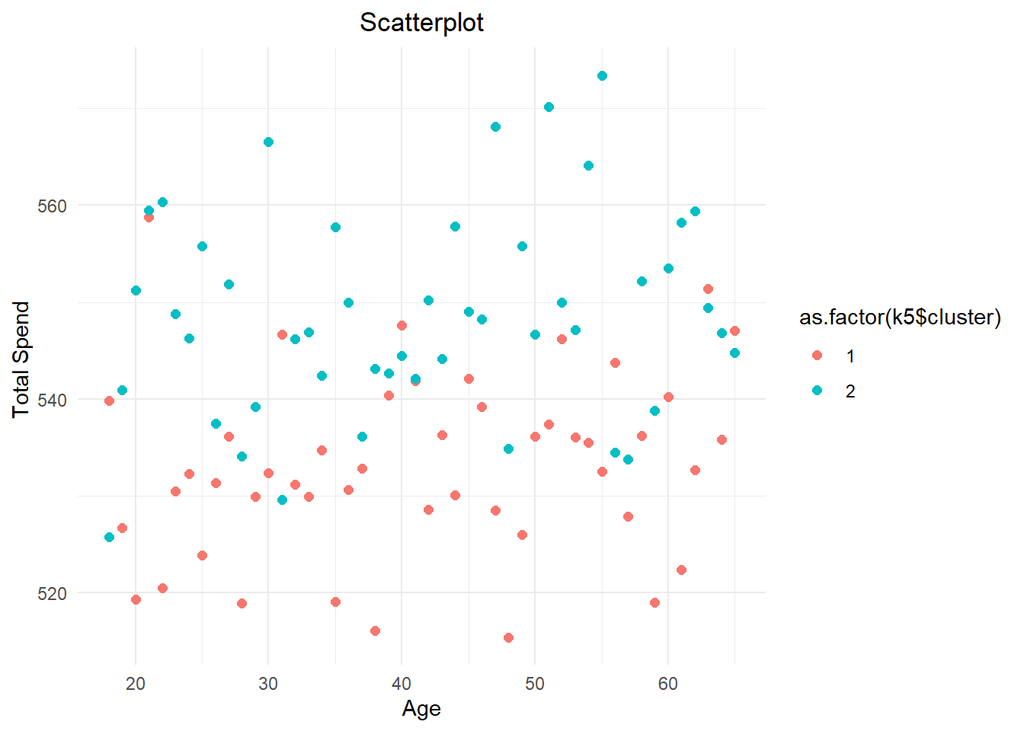

```r
ggplot(data,aes(x=Age,y=Total.Spend,color=as.factor(k5$cluster)))+ stat_summary(fun=mean, geom="point", size=2)+
       labs(x = "Age", y = "Total Spend ") +
  ggtitle("Scatterplot") + theme_minimal()+
  theme(plot.title = element_text(hjust = 0.5))
```

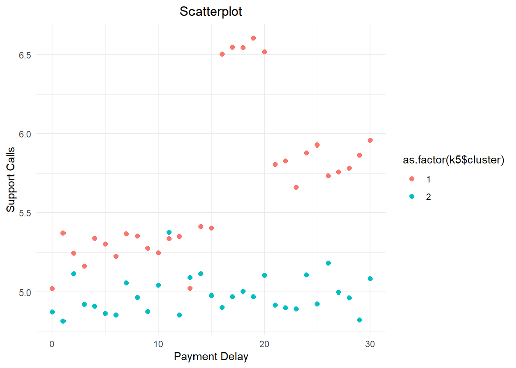

```r
#  scale_color_manual(values = c("0" = "white", "1" = "lightblue"))



ggplot(data,aes(x=Payment.Delay,y=Support.Calls,color=as.factor(k5$cluster)))+stat_summary(fun=mean, geom="point", size=2)+
       labs(x = "Payment Delay", y = "Support Calls") +
  ggtitle("Scatterplot") + theme_minimal()+
  theme(plot.title = element_text(hjust = 0.5))
```

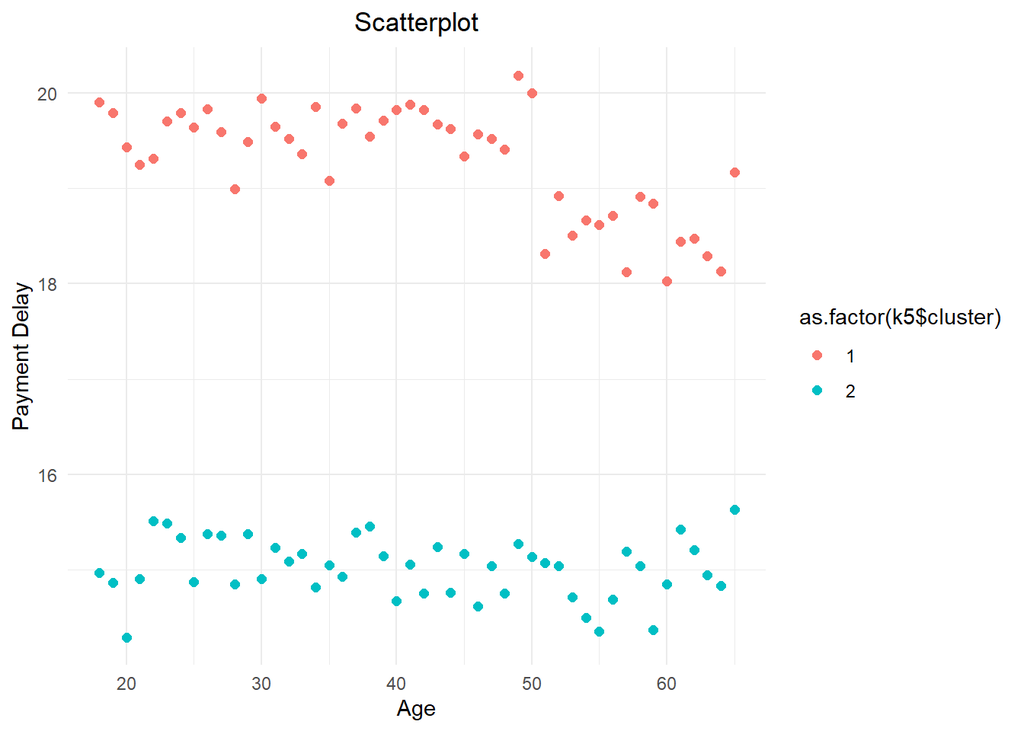

```r
#  scale_color_manual(values = c("0" = "white", "1" = "lightblue"))


ggplot(data,aes(x=Age,y=Payment.Delay,color=as.factor(k5$cluster)))+ stat_summary(fun=mean, geom="point", size=2)+
       labs(x = "Age", y = "Payment Delay") +
  ggtitle("Scatterplot") + theme_minimal()+
  theme(plot.title = element_text(hjust = 0.5))
```

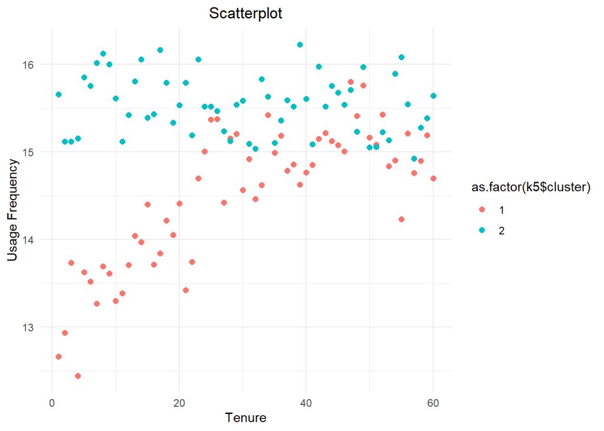

```r
ggplot(data,aes(x=Tenure,y=Usage.Frequency,color=as.factor(k5$cluster)))+ stat_summary(fun=mean, geom="point", size=2)+
       labs(x = "Tenure", y = "Usage Frequency") +
  ggtitle("Scatterplot") + theme_minimal()+
  theme(plot.title = element_text(hjust = 0.5))
```

Thoughts about the above scatterplots:

First Scatterplot: The group with the higher Churn rate (group 1), tended to spend less. The ones that spent the most were in the group with the lower Churn (group 2), meaning the group that churned less.

Second Scatterplot: The group with more support calls, had a higher churn rate. Of course, this makes quite a lot of sense, no one wants to have to take time out of their day to call the corporation for any type of technological or payment issue. Just like we don’t have to hire those people (as much as we love their commitment to our corporation), but we would rather allocate money elsewhere. The more they must call, the less they want to spend money at our corporation. This shows, that from the front end we should really continue to try our best to avoid any issues during the process of interacting with our company

Third Scatterplot: In this scatterplot it shows that those that have a higher payment delay, have a higher churn rate. Also, that is good for us because don’t want to provide our servicing and resources to people that hardly pay us or delay their payments for a long period of time.

Fourth Scatterplot: What I found to be interesting about this scatterplot, is the fact that usage frequency for group 2, which has a lower churn, stays pretty consistent, and the tenure doesn’t. Meanwhile, for Group 1, with a higher churn rate, we see that the only object that is different from group 2, is that the usage frequency is lower.

Final Thoughts:

Looking at our data and analysis in general, we can conclude that there is a promising prevalence of our independent variables impacting our dependent variables. We also can gather very important and useful insights from our collections. Totals spend, typically payment delay, support calls, usage frequency, tenure and even gender surprisingly all impact the churn outcome. The more one spends, the less likely to churn, the more support calls the more likely to churn, the more usage, the less likely to churn. Tenure seems to not necessarily have a major impact, except for the fact looking at our outcome, it almost seemed as though, the longer the ten years, the more churned. Surprisingly, our efforts and marketing tactics should be more targeted toward men, as they churn less frequently, often spend more, and have less payment delay. We even learned about spending habits per contract length. With a monthly contract length, the shortest, customers tended to spend the most.

Utilizing the data collected, we can conclude, that we should essentially focus on the most imperative individual variables. We should not sell the individuals who have any type of payment delay, especially those above 16 days. This could also include doing some type of credit check, because the more delayed the higher the churn. Additionally, we should look at support calls, as that typically impacts churning. We could try to make our interface easier to work with, and make sure our support call professionals are trained and very pleasant to talk to.